# Өгөгдлийг цэвэрлэх ба үндсэн функцууд

### Cleaning dictionary

Use the R package **linelist** and it’s function `clean_variable_spelling()` to clean a data frame with a *cleaning dictionary*. **linelist** is a package developed by [RECON](https://github.com/reconhub/linelist) - the R Epidemics Consortium.

1. Create a cleaning dictionary with 3 columns:
   - A “from” column (the incorrect value)
   - A “to” column (the correct value)
   - A column specifying the column for the changes to be applied (or “.global” to apply to all columns)

Note: .global dictionary entries will be overridden by column-specific dictionary entries.

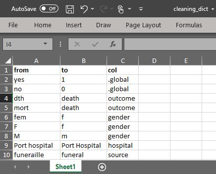

2. Import the dictionary file into R. This example can be downloaded via instructions on the [Download handbook and data] page.

```r
cleaning_dict <- import("cleaning_dict.csv")
```

3. Pass the raw linelist to `clean_variable_spelling()`, specifying to `wordlists =` the cleaning dictionary data frame. The `spelling_vars =` argument can be used to specify which column in the dictionary refers to the columns (3rd by default), or can be set to `NULL` to have the dictionary apply to all character and factor columns. Note this function can take a long time to run.

```r
linelist <- linelist %>%
  linelist::clean_variable_spelling(
    wordlists = cleaning_dict,
    spelling_vars = "col",        # dict column containing column names, defaults to 3rd column in dict
  )
```

Now scroll to the right to see how values have changed - particularly `gender` (lowercase to uppercase), and all the symptoms columns have been transformed from yes/no to 1/0.

| case_id | generation | date_infection | date_onset | date_hospitalisation | date_outcome | outcome | gender | hospital | lon | lat | infector | source | age | age_unit | wt_kg | ht_cm | ct_blood | fever | chills | cough | aches | vomit | temp | time_admission | bmi | age_years |
| --- | --- | --- | --- | --- | --- | --- | --- | --- | --- | --- | --- | --- | --- | --- | --- | --- | --- | --- | --- | --- | --- | --- | --- | --- | --- | --- |
| 5fe599 | 4 | 2014-05-08 | 2014-05-13 | 2014-05-15 |  |  | M | Other | -13.2157351064963 | 8.46897295100924 | f547d6 | other | 2 | years | 27 | 48 | 22 | 0 | 0 | 1 | 0 | 1 | 36.8 |  | 117.1875 | 2 |
| 8689b7 | 4 |  | 2014-05-13 | 2014-05-14 | 2014-05-18 | Recover | F |  | -13.2152339775486 | 8.45171855856465 |  |  | 3 | years | 25 | 59 | 22 |  |  |  |  |  | 36.9 | 09:36 | 71.8184429761563 | 3 |
| 11f8ea | 2 |  | 2014-05-16 | 2014-05-18 | 2014-05-30 | Recover | M | St. Mark's Maternity Hospital (SMMH) | -13.212910703914 | 8.46481700596819 |  |  | 56 | years | 91 | 238 | 21 |  |  |  |  |  | 36.9 | 16:48 | 16.0652496292635 | 56 |
| b8812a | 3 | 2014-05-04 | 2014-05-18 | 2014-05-20 |  |  | F | Port Hospital | -13.2363711169728 | 8.4754761613651 | f90f5f | other | 18 | years | 41 | 135 | 23 | 0 | 0 | 0 | 0 | 0 | 36.8 | 11:22 | 22.4965706447188 | 18 |
| 893f25 | 3 | 2014-05-18 | 2014-05-21 | 2014-05-22 | 2014-05-29 | Recover | M | Military Hospital | -13.2228638912441 | 8.46082377490923 | 11f8ea | other | 3 | years | 36 | 71 | 23 | 0 | 0 | 1 | 0 | 1 | 36.9 | 12:60 | 71.4144019043841 | 3 |
| be99c8 | 3 | 2014-05-03 | 2014-05-22 | 2014-05-23 | 2014-05-24 | Recover | F | Port Hospital | -13.222625321098 | 8.46183062600728 | aec8ec | other | 16 | years | 56 | 116 | 21 | 0 | 0 | 1 | 0 | 1 | 37.6 | 14:13 | 41.6171224732461 | 16 |
| 07e3e8 | 4 | 2014-05-22 | 2014-05-27 | 2014-05-29 | 2014-06-01 | Recover | F |  | -13.2331547837254 | 8.46272931462646 | 893f25 | other | 16 | years | 47 | 87 | 21 |  |  |  |  |  | 37.3 | 14:33 | 62.0953890870657 | 16 |
| 369449 | 4 | 2014-05-28 | 2014-06-02 | 2014-06-03 | 2014-06-07 | Death | F |  | -13.2320975453153 | 8.46144367534271 | 133ee7 | other | 0 | years | 0 | 11 | 22 | 0 | 0 | 1 | 0 | 1 | 37 | 09:25 | 0 | 0 |
| f393b4 | 4 |  | 2014-06-05 | 2014-06-06 | 2014-06-18 | Recover | M |  | -13.2225511595637 | 8.46191259217774 |  |  | 61 | years | 86 | 226 | 22 | 0 | 0 | 1 | 0 | 1 | 36.4 | 11:16 | 16.8376536925366 | 61 |
| 1389ca | 4 |  | 2014-06-05 | 2014-06-07 | 2014-06-09 | Death | F |  | -13.2572163655863 | 8.47292327643506 |  |  | 27 | years | 69 | 174 | 22 | 0 | 0 | 1 | 0 | 0 | 35.9 | 10:55 | 22.7903289734443 | 27 |

[output cut: 40 more lines]

Note that your column names in the cleaning dictionary must correspond to the names *at this point* in your cleaning script. See this [online reference for the linelist package](https://www.repidemicsconsortium.org/linelist/reference/clean_data.html) for more details.

#### Add to pipe chain

**Below, some new columns and column transformations are added to the pipe chain.**

```r
# CLEANING 'PIPE' CHAIN (starts with raw data and pipes it through cleaning steps)
##################################################################################

# begin cleaning pipe chain
###########################
linelist <- linelist_raw %>%

    # standardize column name syntax
    janitor::clean_names() %>%

    # manually re-name columns
           # NEW name             # OLD name
    rename(date_infection       = infection_date,
           date_hospitalisation = hosp_date,
           date_outcome         = date_of_outcome) %>%

    # remove column
    select(-c(row_num, merged_header, x28)) %>%

    # de-duplicate
    distinct() %>%

    # add column
    mutate(bmi = wt_kg / (ht_cm/100)^2) %>%

    # convert class of columns
    mutate(across(contains("date"), as.Date),
           generation = as.numeric(generation),
           age        = as.numeric(age)) %>%

    # add column: delay to hospitalisation
    mutate(days_onset_hosp = as.numeric(date_hospitalisation - date_onset)) %>%

   # ABOVE ARE UPSTREAM CLEANING STEPS ALREADY DISCUSSED
   ###################################################

    # clean values of hospital column
    mutate(hospital = recode(hospital,
                      # OLD = NEW
                      "Mitylira Hopital"  = "Military Hospital",
                      "Mitylira Hospital" = "Military Hospital",
                      "Military Hopital"  = "Military Hospital",
                      "Port Hopital"      = "Port Hospital",
                      "Central Hopital"   = "Central Hospital",
                      "other"             = "Other",
                      "St. Marks Maternity Hopital (SMMH)" = "St. Mark's Maternity Hospital (SMMH)"
                      )) %>%

    mutate(hospital = replace_na(hospital, "Missing")) %>%

    # create age_years column (from age and age_unit)
    mutate(age_years = case_when(
          age_unit == "years" ~ age,
          age_unit == "months" ~ age/12,
          is.na(age_unit) ~ age,
          TRUE ~ NA_real_))
```

## Numeric categories

Here we describe some special approaches for creating categories from numerical columns. Common examples include age categories, groups of lab values, etc. Here we will discuss:

- `age_categories()`, from the **epikit** package
- `cut()`, from **base** R
- `case_when()`
- quantile breaks with `quantile()` and `ntile()`

### Review distribution

For this example we will create an `age_cat` column using the `age_years` column.

```r
#check the class of the linelist variable age
class(linelist$age_years)
```

```
## [1] "numeric"
```

First, examine the distribution of your data, to make appropriate cut-points. See the page on [ggplot basics].

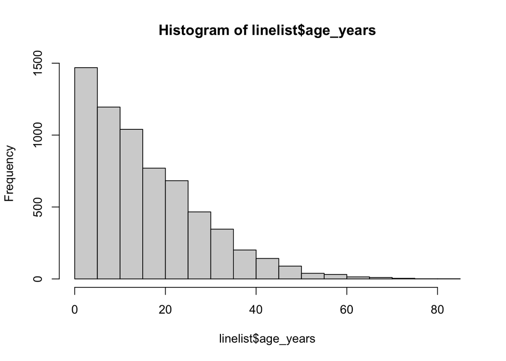

```r
# examine the distribution
hist(linelist$age_years)
```

```r
summary(linelist$age_years, na.rm=T)
```

```
##    Min. 1st Qu.  Median    Mean 3rd Qu.    Max.    NA's
##    0.00    6.00   13.00   16.04   23.00   84.00     107
```

*CAUTION:* Sometimes, numeric variables will import as class “character”. This occurs if there are non-numeric characters in some of the values, for example an entry of “2 months” for age, or (depending on your R locale settings) if a comma is used in the decimals place (e.g. “4,5” to mean four and one half years)..

### `age_categories()`

With the **epikit** package, you can use the `age_categories()` function to easily categorize and label numeric columns (note: this function can be applied to non-age numeric variables too). As a bonum, the output column is automatically an ordered factor.

Here are the required inputs:

- A numeric vector (column)
- The `breakers =` argument - provide a numeric vector of break points for the new groups

First, the simplest example:

```r
# Simple example
################
pacman::p_load(epikit)                    # load package

linelist <- linelist %>%
  mutate(
    age_cat = age_categories(             # create new column
      age_years,                            # numeric column to make groups from
      breakers = c(0, 5, 10, 15, 20,        # break points
                   30, 40, 50, 60, 70)))

# show table
table(linelist$age_cat, useNA = "always")
```

```
##
##   0-4   5-9 10-14 15-19 20-29 30-39 40-49 50-59 60-69   70+  <NA>
##  1227  1223  1048   827  1216   597   251    78    27     7   107
```

The break values you specify are by default the lower bounds - that is, they are included in the “higher” group / the groups are “open” on the lower/left side. As shown below, you can add 1 to each break value to achieve groups that are open at the top/right.

```r
# Include upper ends for the same categories
############################################
linelist <- linelist %>%
  mutate(
    age_cat = age_categories(
      age_years,
      breakers = c(0, 6, 11, 16, 21, 31, 41, 51, 61, 71)))

# show table
table(linelist$age_cat, useNA = "always")
```

```
##
##   0-5  6-10 11-15 16-20 21-30 31-40 41-50 51-60 61-70   71+  <NA>
##  1469  1195  1040   770  1149   547   231    70    24     6   107
```

You can adjust how the labels are displayed with `separator =`. The default is “-”

You can adjust how the top numbers are handled, with the `ceiling =` arguemnt. To set an upper cut-off set `ceiling = TRUE`. In this use, the highest break value provided is a “ceiling” and a category “XX+” is not created. Any values above highest break value (or to `upper =`, if defined) are categorized as `NA`. Below is an example with `ceiling = TRUE`, so that there is no category of XX+ and values above 70 (the highest break value) are assigned as NA.

```r
# With ceiling set to TRUE
##########################
linelist <- linelist %>%
  mutate(
    age_cat = age_categories(
      age_years,
      breakers = c(0, 5, 10, 15, 20, 30, 40, 50, 60, 70),
      ceiling = TRUE)) # 70 is ceiling, all above become NA

# show table
table(linelist$age_cat, useNA = "always")
```

```
##
##   0-4   5-9 10-14 15-19 20-29 30-39 40-49 50-59 60-70  <NA>
##  1227  1223  1048   827  1216   597   251    78    28   113
```

Alternatively, instead of `breakers =`, you can provide all of `lower =`, `upper =`, and `by =`:

- `lower =` The lowest number you want considered - default is 0
- `upper =` The highest number you want considered
- `by =` The number of years between groups

```r
linelist <- linelist %>%
  mutate(
    age_cat = age_categories(
      age_years,
      lower = 0,
      upper = 100,
      by = 10))

# show table
table(linelist$age_cat, useNA = "always")
```

```
##
##   0-9 10-19 20-29 30-39 40-49 50-59 60-69 70-79 80-89 90-99  100+  <NA>
##  2450  1875  1216   597   251    78    27     6     1     0     0   107
```

See the function’s Help page for more details (enter `?age_categories` in the R console).

### `cut()`

`cut()` is a **base** R alternative to `age_categories()`, but I think you will see why `age_categories()` was developed to simplify this process. Some notable differences from `age_categories()` are:

- You do not need to install/load another package
- You can specify whether groups are open/closed on the right/left
- You must provide accurate labels yourself
- If you want 0 included in the lowest group you must specify this

The basic syntax within `cut()` is to first provide the numeric column to be cut (`age_years`), and then the *breaks* argument, which is a numeric vector `c()` of break points. Using `cut()`, the resulting column is an ordered factor.

You can provide a vector of customized labels using the `labels =` argument. As these are manually written, be very careful to ensure they are accurate! Check your work using cross-tabulation, as described below.

An example of `cut()` applied to `age_years` to make the new variable `age_cat` is below:

```r
# Create new variable, by cutting the numeric age variable
# lower break is excluded but upper break is included in each category
linelist <- linelist %>%
  mutate(
    age_cat = cut(
      age_years,
      breaks = c(0, 5, 10, 15, 20,
                 30, 50, 70, 100),
      include.lowest = TRUE         # include 0 in lowest group
      ))

# tabulate the number of observations per group
table(linelist$age_cat, useNA = "always")
```

```
##
##    [0,5]   (5,10]  (10,15]  (15,20]  (20,30]  (30,50]  (50,70] (70,100]
##     1469     1195     1040      770     1149      778       94        6
##     <NA>
##      107
```

**Check your work!!!** Verify that each age value was assigned to the correct category by cross-tabulating the numeric and category columns. Examine assignment of boundary values (e.g. 15, if neighboring categories are 10-15 and 16-20).

```r
# Cross tabulation of the numeric and category columns.
table("Numeric Values" = linelist$age_years,   # names specified in table for clarity.
      "Categories"     = linelist$age_cat,
      useNA = "always")                        # don't forget to examine NA values
```

```
##                     Categories
## Numeric Values       [0,5] (5,10] (10,15] (15,20] (20,30] (30,50] (50,70]
##   0                    136      0       0       0       0       0       0
##   0.0833333333333333     1      0       0       0       0       0       0
##   0.25                   2      0       0       0       0       0       0
##   0.333333333333333      6      0       0       0       0       0       0
##   0.416666666666667      1      0       0       0       0       0       0
##   0.5                    6      0       0       0       0       0       0
##   0.583333333333333      3      0       0       0       0       0       0
##   0.666666666666667      3      0       0       0       0       0       0
##   0.75                   3      0       0       0       0       0       0
##   0.833333333333333      1      0       0       0       0       0       0
##   0.916666666666667      1      0       0       0       0       0       0
##   1                    275      0       0       0       0       0       0
##   1.5                    2      0       0       0       0       0       0
```

[output cut: 163 more lines]

**Re-labeling `NA` values**

You may want to assign `NA` values a label such as “Missing”. Because the new column is class Factor (restricted values), you cannot simply mutate it with `replace_na()`, as this value will be rejected. Instead, use `fct_explicit_na()` from **forcats** as explained in the [Factors] page.

```r
linelist <- linelist %>%

  # cut() creates age_cat, automatically of class Factor
  mutate(age_cat = cut(
    age_years,
    breaks = c(0, 5, 10, 15, 20, 30, 50, 70, 100),
    right = FALSE,
    include.lowest = TRUE,
    labels = c("0-4", "5-9", "10-14", "15-19", "20-29", "30-49", "50-69", "70-100")),

    # make missing values explicit
    age_cat = fct_explicit_na(
      age_cat,
      na_level = "Missing age")  # you can specify the label
  )

# table to view counts
table(linelist$age_cat, useNA = "always")
```

```
##
##         0-4         5-9       10-14       15-19       20-29       30-49
##        1227        1223        1048         827        1216         848
##       50-69      70-100 Missing age        <NA>
##         105           7         107           0
```

**Quickly make breaks and labels**

For a fast way to make breaks and label vectors, use something like below. See the [R basics] page for references on `seq()` and `rep()`.

```r
# Make break points from 0 to 90 by 5
age_seq = seq(from = 0, to = 90, by = 5)
age_seq

# Make labels for the above categories, assuming default cut() settings
age_labels = paste0(age_seq + 1, "-", age_seq + 5)
age_labels

# check that both vectors are the same length
length(age_seq) == length(age_labels)
```

Read more about `cut()` in its Help page by entering `?cut` in the R console.

### Quantile breaks

In common understanding, “quantiles” or “percentiles” typically refer to a value below which a proportion of values fall. For example, the 95th percentile of ages in `linelist` would be the age below which 95% of the age fall.

However in common speech, “quartiles” and “deciles” can also refer to the *groups of data* as equally divided into 4, or 10 groups (note there will be one more break point than group).

To get quantile break points, you can use `quantile()` from the **stats** package from **base** R. You provide a numeric vector (e.g. a column in a dataset) and vector of numeric probability values ranging from 0 to 1.0. The break points are returned as a numeric vector. Explore the details of the statistical methodologies by entering `?quantile`.

- If your input numeric vector has any missing values it is best to set `na.rm = TRUE`
- Set `names = FALSE` to get an un-named numeric vector

```r
quantile(linelist$age_years,               # specify numeric vector to work on
  probs = c(0, .25, .50, .75, .90, .95),   # specify the percentiles you want
  na.rm = TRUE)                            # ignore missing values
```

```
##  0% 25% 50% 75% 90% 95%
##   0   6  13  23  33  41
```

You can use the results of `quantile()` as break points in `age_categories()` or `cut()`. Below we create a new column `deciles` using `cut()` where the breaks are defined using `quantiles()` on `age_years`. Below, we display the results using `tabyl()` from **janitor** so you can see the percentages (see the [Descriptive tables] page). Note how they are not exactly 10% in each group.

```r
linelist %>%                                # begin with linelist
  mutate(deciles = cut(age_years,           # create new column decile as cut() on column age_years
    breaks = quantile(                      # define cut breaks using quantile()
      age_years,                               # operate on age_years
      probs = seq(0, 1, by = 0.1),             # 0.0 to 1.0 by 0.1
      na.rm = TRUE),                           # ignore missing values
    include.lowest = TRUE)) %>%             # for cut() include age 0
  janitor::tabyl(deciles)                   # pipe to table to display
```

```
##  deciles   n    percent valid_percent
##    [0,2] 748 0.11319613    0.11505922
##    (2,5] 721 0.10911017    0.11090601
##    (5,7] 497 0.07521186    0.07644978
##   (7,10] 698 0.10562954    0.10736810
##  (10,13] 635 0.09609564    0.09767728
##  (13,17] 755 0.11425545    0.11613598
##  (17,21] 578 0.08746973    0.08890940
##  (21,26] 625 0.09458232    0.09613906
##  (26,33] 596 0.09019370    0.09167820
##  (33,84] 648 0.09806295    0.09967697
##     <NA> 107 0.01619249            NA
```

### Evenly-sized groups

Another tool to make numeric groups is the the **dplyr** function `ntile()`, which attempts to break your data into n *evenly-sized groups* - *but be aware that unlike with `quantile()` the same value could appear in more than one group.* Provide the numeric vector and then the number of groups. The values in the new column created is just group “numbers” (e.g. 1 to 10), not the range of values themselves as when using `cut()`.

```r
# make groups with ntile()
ntile_data <- linelist %>%
  mutate(even_groups = ntile(age_years, 10))

# make table of counts and proportions by group
ntile_table <- ntile_data %>%
  janitor::tabyl(even_groups)

# attach min/max values to demonstrate ranges
ntile_ranges <- ntile_data %>%
  group_by(even_groups) %>%
  summarise(
    min = min(age_years, na.rm=T),
    max = max(age_years, na.rm=T)
  )
# combine and print - note that values are present in multiple groups
left_join(ntile_table, ntile_ranges, by = "even_groups")
```

```
##  even_groups   n    percent valid_percent min  max
##            1 651 0.09851695    0.10013844   0    2
##            2 650 0.09836562    0.09998462   2    5
##            3 650 0.09836562    0.09998462   5    7
##            4 650 0.09836562    0.09998462   7   10
##            5 650 0.09836562    0.09998462  10   13
##            6 650 0.09836562    0.09998462  13   17
##            7 650 0.09836562    0.09998462  17   21
##            8 650 0.09836562    0.09998462  21   26
##            9 650 0.09836562    0.09998462  26   33
##           10 650 0.09836562    0.09998462  33   84
##           NA 107 0.01619249            NA Inf -Inf
```

### `case_when()`

It is possible to use the **dplyr** function `case_when()` to create categories from a numeric column, but it is easier to use `age_categories()` from **epikit** or `cut()` because these will create an ordered factor automatically.

If using `case_when()`, please review the proper use as described earlier in the Re-code values section of this page. Also be aware that all right-hand side values must be of the same class. Thus, if you want `NA` on the right-side you should either write “Missing” or use the special `NA` value `NA_character_`.

### Add to pipe chain

Below, code to create two categorical age columns is added to the cleaning pipe chain:

```r
# CLEANING 'PIPE' CHAIN (starts with raw data and pipes it through cleaning steps)
##################################################################################

# begin cleaning pipe chain
###########################
linelist <- linelist_raw %>%

    # standardize column name syntax
    janitor::clean_names() %>%

    # manually re-name columns
           # NEW name             # OLD name
    rename(date_infection       = infection_date,
           date_hospitalisation = hosp_date,
           date_outcome         = date_of_outcome) %>%

    # remove column
    select(-c(row_num, merged_header, x28)) %>%

    # de-duplicate
    distinct() %>%

    # add column
    mutate(bmi = wt_kg / (ht_cm/100)^2) %>%

    # convert class of columns
    mutate(across(contains("date"), as.Date),
           generation = as.numeric(generation),
           age        = as.numeric(age)) %>%

    # add column: delay to hospitalisation
    mutate(days_onset_hosp = as.numeric(date_hospitalisation - date_onset)) %>%

    # clean values of hospital column
    mutate(hospital = recode(hospital,
                      # OLD = NEW
                      "Mitylira Hopital"  = "Military Hospital",
                      "Mitylira Hospital" = "Military Hospital",
                      "Military Hopital"  = "Military Hospital",
                      "Port Hopital"      = "Port Hospital",
                      "Central Hopital"   = "Central Hospital",
                      "other"             = "Other",
                      "St. Marks Maternity Hopital (SMMH)" = "St. Mark's Maternity Hospital (SMMH)"
                      )) %>%

    mutate(hospital = replace_na(hospital, "Missing")) %>%

    # create age_years column (from age and age_unit)
    mutate(age_years = case_when(
          age_unit == "years" ~ age,
          age_unit == "months" ~ age/12,
          is.na(age_unit) ~ age,
          TRUE ~ NA_real_)) %>%

    # ABOVE ARE UPSTREAM CLEANING STEPS ALREADY DISCUSSED
    ###################################################
    mutate(
          # age categories: custom
          age_cat = epikit::age_categories(age_years, breakers = c(0, 5, 10, 15, 20, 30, 50, 70)),

          # age categories: 0 to 85 by 5s
          age_cat5 = epikit::age_categories(age_years, breakers = seq(0, 85, 5)))
```

## Add rows

### One-by-one

Adding rows one-by-one manually is tedious but can be done with `add_row()` from **dplyr**. Remember that each column must contain values of only one class (either character, numeric, logical, etc.). So adding a row requires nuance to maintain this.

```r
linelist <- linelist %>%
  add_row(row_num = 666,
          case_id = "abc",
          generation = 4,
          `infection date` = as.Date("2020-10-10"),
          .before = 2)
```

Use `.before` and `.after.` to specify the placement of the row you want to add. `.before = 3` will put the new row before the current 3rd row. The default behavior is to add the row to the end. Columns not specified will be left empty (`NA`).

The new *row number* may look strange (“…23”) but the row numbers in the pre-existing rows *have* changed. So if using the command twice, examine/test the insertion carefully.

If a class you provide is off you will see an error like this:

```
Error: Can't combine ..1$infection date <date> and ..2$infection date <character>.
```

(when inserting a row with a date value, remember to wrap the date in the function `as.Date()` like `as.Date("2020-10-10")`).

### Bind rows

To combine datasets together by binding the rows of one dataframe to the bottom of another data frame, you can use `bind_rows()` from **dplyr**. This is explained in more detail in the page [Joining data].

## Filter rows

A typical cleaning step after you have cleaned the columns and re-coded values is to *filter* the data frame for specific rows using the **dplyr** verb `filter()`.

Within `filter()`, specify the logic that must be `TRUE` for a row in the dataset to be kept. Below we show how to filter rows based on simple and complex logical conditions.

### Simple filter

This simple example re-defines the dataframe `linelist` as itself, having filtered the rows to meet a logical condition. **Only the rows where the logical statement within the parentheses evaluates to `TRUE` are kept.**

In this example, the logical statement is `gender == "f"`, which is asking whether the value in the column `gender` is equal to “f” (case sensitive).

```r
linelist <- linelist %>%
  filter(gender == "f")   # keep only rows where gender is equal to "f"
```

### Filter out missing values

It is fairly common to want to filter out rows that have missing values. Resist the urge to write `filter(!is.na(column) & !is.na(column))` and instead use the **tidyr** function that is custom-built for this purpose: `drop_na()`. If run with empty parentheses, it removes rows with *any* missing values. Alternatively, you can provide names of specific columns to be evaluated for missingness, or use the “tidyselect” helper functions described above.

```r
linelist %>%
  drop_na(case_id, age_years)  # drop rows with missing values for case_id or age_years
```

See the page on [Missing data] for many techniques to analyse and manage missingness in your data.

### Filter by row number

In a data frame or tibble, each row will usually have a “row number” that (when seen in R Viewer) appears to the left of the first column. It is not itself a true column in the data, but it can be used in a `filter()` statement.

To filter based on “row number”, you can use the **dplyr** function `row_number()` with open parentheses as part of a logical filtering statement. Often you will use the `%in%` operator and a range of numbers as part of that logical statement, as shown below. To see the *first* N rows, you can also use the special **dplyr** function `head()`.

```r
# View first 100 rows
linelist %>% head(100)     # or use tail() to see the n last rows

# Show row 5 only
linelist %>% filter(row_number() == 5)

# View rows 2 through 20, and three specific columns
linelist %>% filter(row_number() %in% 2:20) %>% select(date_onset, outcome, age)
```

You can also convert the row numbers to a true column by piping your data frame to the **tibble** function `rownames_to_column()` (do not put anything in the parentheses).

### Complex filter

More complex logical statements can be constructed using parentheses `( )`, OR `|`, negate `!`, `%in%`, and AND `&` operators. An example is below:

Note: You can use the `!` operator in front of a logical criteria to negate it. For example, `!is.na(column)` evaluates to true if the column value is *not* missing. Likewise `!column %in% c("a", "b", "c")` evaluates to true if the column value is *not* in the vector.

#### Examine the data

Below is a simple one-line command to create a histogram of onset dates. See that a second smaller outbreak from 2012-2013 is also included in this raw dataset. **For our analyses, we want to remove entries from this earlier outbreak.**

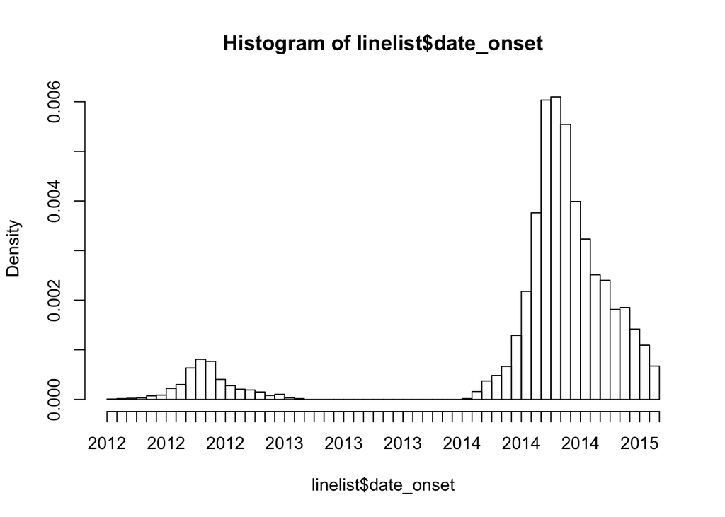

```r
hist(linelist$date_onset, breaks = 50)
```

#### How filters handle missing numeric and date values

Can we just filter by `date_onset` to rows after June 2013? **Caution! Applying the code `filter(date_onset > as.Date("2013-06-01")))` would remove any rows in the later epidemic with a missing date of onset!**

*DANGER:* Filtering to greater than (>) or less than (<) a date or number can remove any rows with missing values (`NA`)! This is because `NA` is treated as infinitely large and small.

*(See the page on [Working with dates] for more information on working with dates and the package **lubridate**)*

#### Design the filter

Examine a cross-tabulation to make sure we exclude only the correct rows:

```r
table(Hospital  = linelist$hospital,                     # hospital name
      YearOnset = lubridate::year(linelist$date_onset),  # year of date_onset
      useNA     = "always")                              # show missing values
```

```
##                                       YearOnset
## Hospital                               2012 2013 2014 2015 <NA>
##   Central Hospital                        0    0  351   99   18
##   Hospital A                            229   46    0    0   15
##   Hospital B                            227   47    0    0   15
##   Military Hospital                       0    0  676  200   34
##   Missing                                 0    0 1117  318   77
##   Other                                   0    0  684  177   46
##   Port Hospital                           9    1 1372  347   75
##   St. Mark's Maternity Hospital (SMMH)    0    0  322   93   13
##   <NA>                                    0    0    0    0    0
```

What other criteria can we filter on to remove the first outbreak (in 2012 & 2013) from the dataset? We see that:

- The first epidemic in 2012 & 2013 occurred at Hospital A, Hospital B, and that there were also 10 cases at Port Hospital.
- Hospitals A & B did *not* have cases in the second epidemic, but Port Hospital did.

We want to exclude:

```r
linelist <- linelist %>%
  # keep rows where onset is after 1 June 2013 OR where onset is missing and it was a hospital OTHER than Hospital A or B
  filter(date_onset > as.Date("2013-06-01") | (is.na(date_onset) & !hospital %in% c("Hospital A", "Hospital B")))

nrow(linelist)
```

```
## [1] 6019
```

When we re-make the cross-tabulation, we see that Hospitals A & B are removed completely, and the 10 Port Hospital cases from 2012 & 2013 are removed, and all other values are the same - just as we wanted.

```r
table(Hospital  = linelist$hospital,                     # hospital name
      YearOnset = lubridate::year(linelist$date_onset),  # year of date_onset
      useNA     = "always")                              # show missing values
```

```
##                                       YearOnset
## Hospital                               2014 2015 <NA>
##   Central Hospital                      351   99   18
##   Military Hospital                     676  200   34
##   Missing                              1117  318   77
##   Other                                 684  177   46
##   Port Hospital                        1372  347   75
##   St. Mark's Maternity Hospital (SMMH)  322   93   13
##   <NA>                                    0    0    0
```

Multiple statements can be included within one filter command (separated by commas), or you can always pipe to a separate filter() command for clarity.

*Note: some readers may notice that it would be easier to just filter by `date_hospitalisation` because it is 100% complete with no missing values. This is true. But `date_onset` is used for purposes of demonstrating a complex filter.*

### Standalone

Filtering can also be done as a stand-alone command (not part of a pipe chain). Like other **dplyr** verbs, in this case the first argument must be the dataset itself.

```r
# dataframe <- filter(dataframe, condition(s) for rows to keep)

linelist <- filter(linelist, !is.na(case_id))
```

You can also use **base** R to subset using square brackets which reflect the [rows, columns] that you want to retain.

```r
# dataframe <- dataframe[row conditions, column conditions] (blank means keep all)

linelist <- linelist[!is.na(case_id), ]
```

### Quickly review records

Often you want to quickly review a few records, for only a few columns. The **base** R function `View()` will print a data frame for viewing in your RStudio.

View the linelist in RStudio:

```r
View(linelist)
```

Here are two examples of viewing specific cells (specific rows, and specific columns):

**With dplyr functions `filter()` and `select()`:**

Within `View()`, pipe the dataset to `filter()` to keep certain rows, and then to `select()` to keep certain columns. For example, to review onset and hospitalization dates of 3 specific cases:

```r
View(linelist %>%
       filter(case_id %in% c("11f8ea", "76b97a", "47a5f5")) %>%
       select(date_onset, date_hospitalisation))
```

You can achieve the same with **base** R syntax, using brackets `[ ]` to subset you want to see.

```r
View(linelist[linelist$case_id %in% c("11f8ea", "76b97a", "47a5f5"), c("date_onset", "date_hospitalisation")])
```

#### Add to pipe chain

```r
# CLEANING 'PIPE' CHAIN (starts with raw data and pipes it through cleaning steps)
##################################################################################

# begin cleaning pipe chain
###########################
linelist <- linelist_raw %>%

    # standardize column name syntax
    janitor::clean_names() %>%

    # manually re-name columns
           # NEW name             # OLD name
    rename(date_infection       = infection_date,
           date_hospitalisation = hosp_date,
           date_outcome         = date_of_outcome) %>%

    # remove column
    select(-c(row_num, merged_header, x28)) %>%

    # de-duplicate
    distinct() %>%

    # add column
    mutate(bmi = wt_kg / (ht_cm/100)^2) %>%

    # convert class of columns
    mutate(across(contains("date"), as.Date),
           generation = as.numeric(generation),
           age        = as.numeric(age)) %>%

    # add column: delay to hospitalisation
    mutate(days_onset_hosp = as.numeric(date_hospitalisation - date_onset)) %>%

    # clean values of hospital column
    mutate(hospital = recode(hospital,
                      # OLD = NEW
                      "Mitylira Hopital"  = "Military Hospital",
                      "Mitylira Hospital" = "Military Hospital",
                      "Military Hopital"  = "Military Hospital",
                      "Port Hopital"      = "Port Hospital",
                      "Central Hopital"   = "Central Hospital",
                      "other"             = "Other",
                      "St. Marks Maternity Hopital (SMMH)" = "St. Mark's Maternity Hospital (SMMH)"
                      )) %>%

    mutate(hospital = replace_na(hospital, "Missing")) %>%

    # create age_years column (from age and age_unit)
    mutate(age_years = case_when(
          age_unit == "years" ~ age,
          age_unit == "months" ~ age/12,
          is.na(age_unit) ~ age,
          TRUE ~ NA_real_)) %>%

    mutate(
          # age categories: custom
          age_cat = epikit::age_categories(age_years, breakers = c(0, 5, 10, 15, 20, 30, 50, 70)),

          # age categories: 0 to 85 by 5s
          age_cat5 = epikit::age_categories(age_years, breakers = seq(0, 85, 5))) %>%

    # ABOVE ARE UPSTREAM CLEANING STEPS ALREADY DISCUSSED
    ###################################################
    filter(
          # keep only rows where case_id is not missing
          !is.na(case_id),

          # also filter to keep only the second outbreak
          date_onset > as.Date("2013-06-01") | (is.na(date_onset) & !hospital %in% c("Hospital A", "Hospital B")))
```

## Row-wise calculations

If you want to perform a calculation within a row, you can use `rowwise()` from **dplyr**. See this online vignette on [row-wise calculations](https://cran.r-project.org/web/packages/dplyr/vignettes/rowwise.html).  
For example, this code applies `rowwise()` and then creates a new column that sums the number of the specified symptom columns that have value “yes”, for each row in the linelist. The columns are specified within `sum()` by name within a vector `c()`. `rowwise()` is essentially a special kind of `group_by()`, so it is best to use `ungroup()` when you are done (page on [Grouping data]).

```r
linelist %>%
  rowwise() %>%
  mutate(num_symptoms = sum(c(fever, chills, cough, aches, vomit) == "yes")) %>%
  ungroup() %>%
  select(fever, chills, cough, aches, vomit, num_symptoms) # for display
```

```
## # A tibble: 5,888 × 6
##    fever chills cough aches vomit num_symptoms
##    <chr> <chr>  <chr> <chr> <chr>        <int>
##  1 no    no     yes   no    yes              2
##  2 <NA>  <NA>   <NA>  <NA>  <NA>            NA
##  3 <NA>  <NA>   <NA>  <NA>  <NA>            NA
##  4 no    no     no    no    no               0
##  5 no    no     yes   no    yes              2
##  6 no    no     yes   no    yes              2
##  7 <NA>  <NA>   <NA>  <NA>  <NA>            NA
##  8 no    no     yes   no    yes              2
##  9 no    no     yes   no    yes              2
## 10 no    no     yes   no    no               1
## # … with 5,878 more rows
```

As you specify the column to evaluate, you may want to use the “tidyselect” helper functions described in the `select()` section of this page. You just have to make one adjustment (because you are not using them within a **dplyr** function like `select()` or `summarise()`).

Put the column-specification criteria within the **dplyr** function `c_across()`. This is because `c_across` ([documentation](https://dplyr.tidyverse.org/reference/c_across.html)) is designed to work with `rowwise()` specifically. For example, the following code:

- Applies `rowwise()` so the following operation (`sum()`) is applied within each row (not summing entire columns)
- Creates new column `num_NA_dates`, defined for each row as the number of columns (with name containing “date”) for which `is.na()` evaluated to TRUE (they are missing data).
- `ungroup()` to remove the effects of `rowwise()` for subsequent steps

```r
linelist %>%
  rowwise() %>%
  mutate(num_NA_dates = sum(is.na(c_across(contains("date"))))) %>%
  ungroup() %>%
  select(num_NA_dates, contains("date")) # for display
```

```
## # A tibble: 5,888 × 5
##    num_NA_dates date_infection date_onset date_hospitalisation date_outcome
##           <int> <date>         <date>     <date>               <date>
##  1            1 2014-05-08     2014-05-13 2014-05-15           NA
##  2            1 NA             2014-05-13 2014-05-14           2014-05-18
##  3            1 NA             2014-05-16 2014-05-18           2014-05-30
##  4            1 2014-05-04     2014-05-18 2014-05-20           NA
##  5            0 2014-05-18     2014-05-21 2014-05-22           2014-05-29
##  6            0 2014-05-03     2014-05-22 2014-05-23           2014-05-24
##  7            0 2014-05-22     2014-05-27 2014-05-29           2014-06-01
##  8            0 2014-05-28     2014-06-02 2014-06-03           2014-06-07
##  9            1 NA             2014-06-05 2014-06-06           2014-06-18
## 10            1 NA             2014-06-05 2014-06-07           2014-06-09
## # … with 5,878 more rows
```

You could also provide other functions, such as `max()` to get the latest or most recent date for each row:

```r
linelist %>%
  rowwise() %>%
  mutate(latest_date = max(c_across(contains("date")), na.rm=T)) %>%
  ungroup() %>%
  select(latest_date, contains("date"))  # for display
```

```
## # A tibble: 5,888 × 5
##    latest_date date_infection date_onset date_hospitalisation date_outcome
##    <date>      <date>         <date>     <date>               <date>
##  1 2014-05-15  2014-05-08     2014-05-13 2014-05-15           NA
##  2 2014-05-18  NA             2014-05-13 2014-05-14           2014-05-18
##  3 2014-05-30  NA             2014-05-16 2014-05-18           2014-05-30
##  4 2014-05-20  2014-05-04     2014-05-18 2014-05-20           NA
##  5 2014-05-29  2014-05-18     2014-05-21 2014-05-22           2014-05-29
##  6 2014-05-24  2014-05-03     2014-05-22 2014-05-23           2014-05-24
##  7 2014-06-01  2014-05-22     2014-05-27 2014-05-29           2014-06-01
##  8 2014-06-07  2014-05-28     2014-06-02 2014-06-03           2014-06-07
##  9 2014-06-18  NA             2014-06-05 2014-06-06           2014-06-18
## 10 2014-06-09  NA             2014-06-05 2014-06-07           2014-06-09
## # … with 5,878 more rows
```

## Arrange and sort

Use the **dplyr** function `arrange()` to sort or order the rows by column values.

Simple list the columns in the order they should be sorted on. Specify `.by_group = TRUE` if you want the sorting to to first occur by any *groupings* applied to the data (see page on [Grouping data]).

By default, column will be sorted in “ascending” order (which applies to numeric and also to character columns). You can sort a variable in “descending” order by wrapping it with `desc()`.

Sorting data with `arrange()` is particularly useful when making [Tables for presentation], using `slice()` to take the “top” rows per group, or setting factor level order by order of appearance.

For example, to sort the our linelist rows by `hospital`, then by `date_onset` in descending order, we would use:

```r
linelist %>%
   arrange(hospital, desc(date_onset))
```